# German Cars Market

Nour ElDeen Khaled

10/11/2023

# 1 introduction

I will be walking you through my R code of the Germany Cars Dataset that was scraped from [AutoScout24](https://www.autoscout24.com/) that i chose to be the case study project I completed as part of the Google Data Analytics Professional Certificate. This tutorial would be used to walk my team of analysts at the Germany Cars Dataset through my steps and thought processes while deriving insights from this data set. I will include project overview in the form of a statement of the business task, data overview, data clean up documentation, summary of data analysis, and a summary of insights that would be presented to you.

If you have any questions, please feel free to email me at noureldeen.khaled.elsayed@gmail.com or via [LinkedIn](https://www.linkedin.com/in/nour-khaled-b04987272/).

## 1.1 Project Overview

In this project, I will be using Germany Cars dataset to explore the cars market in germany and how would different attributes affect on it.

In this dataset, Some of the questions that needed to be asked are:

1. what is the average price for a german car by company the most expensive 15 and the cheapest 15 ?
2. what is the most common type of gear in cars in germany and what is its average price ?
3. what is the relationship between mileage and other columns ?

## 1.2 Data Overview

### 1.2.1 Source

I have downloaded the Germany Cars Dataset from [kaggle on this link](https://www.kaggle.com/datasets/ander289386/cars-germany/data) and Dataset set was scrapped automaticlly By ZenRows From the website [AutoScout24](https://www.autoscout24.com/)

Sources:

[Kaggle Dataset](https://www.kaggle.com/datasets/ander289386/cars-germany/data)

[Website scrapped from](https://www.autoscout24.com/).

# 2 Process Data

**Libraries i used and needed for the project**

```r
# install.packages("plotrix")
library(plotrix)
library(readr)
library(tidyverse)
```

**read the CSV and print it**

```r
my_data <- read.csv("D:/coursera google data analysis/professional/Course 8- Capstone/Data sets downloaded/germany cars data set/autoscout24-germany-dataset.csv")
my_data %>%
  head(15) %>%
  print()
```

```
##    mileage          make   model              fuel      gear offerType price
## 1   235000           BMW     316            Diesel    Manual      Used  6800
## 2    92800    Volkswagen    Golf          Gasoline    Manual      Used  6877
## 3   149300          SEAT    Exeo          Gasoline    Manual      Used  6900
## 4    96200       Renault  Megane          Gasoline    Manual      Used  6950
## 5   156000       Peugeot     308          Gasoline    Manual      Used  6950
## 6   147000        Toyota   Auris Electric/Gasoline Automatic      Used  6950
## 7    91894       Renault  Scenic            Diesel    Manual      Used  6970
## 8   127500          Opel  Zafira          Gasoline    Manual      Used  6972
## 9   115000         Mazda       3          Gasoline Automatic      Used  6980
## 10     104          Ford Transit            Diesel    Manual      Used  6990
## 11   59580          Opel  Meriva            Diesel Automatic      Used  6990
## 12   84000    Volkswagen    Golf          Gasoline    Manual      Used  6990
## 13  427000 Mercedes-Benz   E 250            Diesel Automatic      Used  6990
## 14  109000     Chevrolet Orlando          Gasoline    Manual      Used  6990
```

[output cut: 17 more lines]

# 3 exploring and cleaning the data

```r
dim(my_data)
```

```
## [1] 46405     9
```

```r
#View(my_data)

names(my_data)
```

```
## [1] "mileage"   "make"      "model"     "fuel"      "gear"      "offerType"
## [7] "price"     "hp"        "year"
```

```r
glimpse(my_data)
```

```
## Rows: 46,405
## Columns: 9
## $ mileage   <int> 235000, 92800, 149300, 96200, 156000, 147000, 91894, 127500,~
## $ make      <chr> "BMW", "Volkswagen", "SEAT", "Renault", "Peugeot", "Toyota",~
## $ model     <chr> "316", "Golf", "Exeo", "Megane", "308", "Auris", "Scenic", "~
## $ fuel      <chr> "Diesel", "Gasoline", "Gasoline", "Gasoline", "Gasoline", "E~
## $ gear      <chr> "Manual", "Manual", "Manual", "Manual", "Manual", "Automatic~
## $ offerType <chr> "Used", "Used", "Used", "Used", "Used", "Used", "Used", "Use~
## $ price     <int> 6800, 6877, 6900, 6950, 6950, 6950, 6970, 6972, 6980, 6990, ~
## $ hp        <int> 116, 122, 160, 110, 156, 99, 131, 116, 150, 86, 101, 105, 20~
## $ year      <int> 2011, 2011, 2011, 2011, 2011, 2011, 2011, 2011, 2011, 2011, ~
```

```r
unique(my_data$make)
```

```
##  [1] "BMW"               "Volkswagen"        "SEAT"
##  [4] "Renault"           "Peugeot"           "Toyota"
##  [7] "Opel"              "Mazda"             "Ford"
## [10] "Mercedes-Benz"     "Chevrolet"         "Audi"
## [13] "Fiat"              "Kia"               "Dacia"
## [16] "MINI"              "Hyundai"           "Skoda"
## [19] "Citroen"           "Infiniti"          "Suzuki"
## [22] "SsangYong"         "smart"             "Cupra"
## [25] "Volvo"             "Jaguar"            "Porsche"
## [28] "Nissan"            "Honda"             "Lada"
## [31] "Mitsubishi"        "Others"            "Lexus"
## [34] "Jeep"              "Maserati"          "Bentley"
## [37] "Land"              "Alfa"              "Subaru"
## [40] "Dodge"             "Microcar"          "Lamborghini"
## [43] "Baic"              "Tesla"             "Chrysler"
## [46] "9ff"               "McLaren"           "Aston"
## [49] "Rolls-Royce"       "Alpine"            "Lancia"
## [52] "Abarth"            "DS"                "Daihatsu"
## [55] "Ligier"            "Ferrari"           "Caravans-Wohnm"
## [58] "Aixam"             "Piaggio"           "Zhidou"
## [61] "Morgan"            "Maybach"           "Tazzari"
## [64] "Trucks-Lkw"        "RAM"               "Iveco"
## [67] "DAF"               "Alpina"            "Polestar"
## [70] "Brilliance"        "FISKER"            "Cadillac"
## [73] "Trailer-AnhÃ¤nger" "Isuzu"             "Corvette"
## [76] "DFSK"              "Estrima"
```

```r
unique(my_data$fuel)
```

```
##  [1] "Diesel"            "Gasoline"          "Electric/Gasoline"
##  [4] "-/- (Fuel)"        "Electric"          "Electric/Diesel"
##  [7] "CNG"               "LPG"               "Others"
## [10] "Hydrogen"          "Ethanol"
```

```r
unique(my_data$gear)
```

```
## [1] "Manual"         "Automatic"      ""               "Semi-automatic"
```

```r
unique(my_data$offerType)
```

```
## [1] "Used"           "Demonstration"  "Employee's car" "Pre-registered"
## [5] "New"
```

```r
unique(my_data$year)
```

```
##  [1] 2011 2012 2013 2014 2015 2016 2017 2018 2019 2020 2021
```

**Checking for the nulls**

```r
my_data %>%
  select(everything()) %>%
  filter(!complete.cases(.)) %>%
  head(10)
```

|  | mileage | make | model | fuel | gear | offerType | price | hp | year |
| --- | --- | --- | --- | --- | --- | --- | --- | --- | --- |
| 1 | 36018 | Mitsubishi | Space Star | Gasoline | Manual | Used | 6222 | NA | 2015 |
| 2 | 36018 | Mitsubishi | Space Star | Gasoline | Manual | Used | 6222 | NA | 2015 |
| 3 | 129375 | Peugeot | 207 | Gasoline | Manual | Used | 5950 | NA | 2013 |
| 4 | 129375 | Peugeot | 207 | Gasoline | Manual | Used | 5950 | NA | 2013 |
| 5 | 71113 | Opel | Corsa | Gasoline | Manual | Used | 5666 | NA | 2012 |
| 6 | 5 | Aixam |  | Electric | Automatic | Pre-registered | 22180 | NA | 2021 |
| 7 | 72109 | Ford | Fiesta | Gasoline | Manual | Used | 6222 | NA | 2013 |
| 8 | 71113 | Opel | Corsa | Gasoline | Manual | Used | 5666 | NA | 2012 |
| 9 | 72109 | Ford | Fiesta | Gasoline | Manual | Used | 6222 | NA | 2013 |
| 10 | 139 | Renault | Twingo | Electric | Automatic | Demonstration | 15990 | NA | 2021 |

**checking for duplicates**

```r
# print(my_data[duplicated(my_data),])
```

**choosing the distinct values**

```r
data_distinct <- distinct(my_data)
data_distinct %>%
  head(10)
```

|  | mileage | make | model | fuel | gear | offerType | price | hp | year |
| --- | --- | --- | --- | --- | --- | --- | --- | --- | --- |
| 1 | 235000 | BMW | 316 | Diesel | Manual | Used | 6800 | 116 | 2011 |
| 2 | 92800 | Volkswagen | Golf | Gasoline | Manual | Used | 6877 | 122 | 2011 |
| 3 | 149300 | SEAT | Exeo | Gasoline | Manual | Used | 6900 | 160 | 2011 |
| 4 | 96200 | Renault | Megane | Gasoline | Manual | Used | 6950 | 110 | 2011 |
| 5 | 156000 | Peugeot | 308 | Gasoline | Manual | Used | 6950 | 156 | 2011 |
| 6 | 147000 | Toyota | Auris | Electric/Gasoline | Automatic | Used | 6950 | 99 | 2011 |
| 7 | 91894 | Renault | Scenic | Diesel | Manual | Used | 6970 | 131 | 2011 |
| 8 | 127500 | Opel | Zafira | Gasoline | Manual | Used | 6972 | 116 | 2011 |
| 9 | 115000 | Mazda | 3 | Gasoline | Automatic | Used | 6980 | 150 | 2011 |
| 10 | 104 | Ford | Transit | Diesel | Manual | Used | 6990 | 86 | 2011 |

**deleting the Na in the data in the hp column because it doesn’t matter**

```r
sum(is.na(data_distinct))
```

```
## [1] 24
```

```r
colSums(is.na(data_distinct))
```

```
##   mileage      make     model      fuel      gear offerType     price        hp
##         0         0         0         0         0         0         0        24
##      year
##         0
```

```r
My_cleaned_data <- na.omit(data_distinct)
My_cleaned_data %>%
  head(10)
```

|  | mileage | make | model | fuel | gear | offerType | price | hp | year |
| --- | --- | --- | --- | --- | --- | --- | --- | --- | --- |
| 1 | 235000 | BMW | 316 | Diesel | Manual | Used | 6800 | 116 | 2011 |
| 2 | 92800 | Volkswagen | Golf | Gasoline | Manual | Used | 6877 | 122 | 2011 |
| 3 | 149300 | SEAT | Exeo | Gasoline | Manual | Used | 6900 | 160 | 2011 |
| 4 | 96200 | Renault | Megane | Gasoline | Manual | Used | 6950 | 110 | 2011 |
| 5 | 156000 | Peugeot | 308 | Gasoline | Manual | Used | 6950 | 156 | 2011 |
| 6 | 147000 | Toyota | Auris | Electric/Gasoline | Automatic | Used | 6950 | 99 | 2011 |
| 7 | 91894 | Renault | Scenic | Diesel | Manual | Used | 6970 | 131 | 2011 |
| 8 | 127500 | Opel | Zafira | Gasoline | Manual | Used | 6972 | 116 | 2011 |
| 9 | 115000 | Mazda | 3 | Gasoline | Automatic | Used | 6980 | 150 | 2011 |
| 10 | 104 | Ford | Transit | Diesel | Manual | Used | 6990 | 86 | 2011 |

# 4 Insights, Questions and answers

#### 4.0.0.1 **What are the most popular German car brands and models in the dataset and what are the least popular?**

```r
counts <- My_cleaned_data %>%
  group_by(make, model) %>%
  summarize(count = n())
```

##### 4.0.0.1.1 **most common cars in germany**

```r
counts2 <- counts %>%
  arrange(desc(counts$count)) %>%
  head(10) %>%
  print()
```

```
## # A tibble: 10 x 3
## # Groups:   make [5]
##    make       model   count
##    <chr>      <chr>   <int>
##  1 Volkswagen Golf     1453
##  2 Opel       Corsa    1395
##  3 Ford       Fiesta   1235
##  4 Opel       Astra    1142
##  5 Ford       Focus     948
##  6 Volkswagen up!       921
##  7 Volkswagen Polo      853
##  8 Skoda      Fabia     832
##  9 smart      forTwo    698
## 10 Skoda      Octavia   648
```

##### 4.0.0.1.2 **Plot for the most common cars**

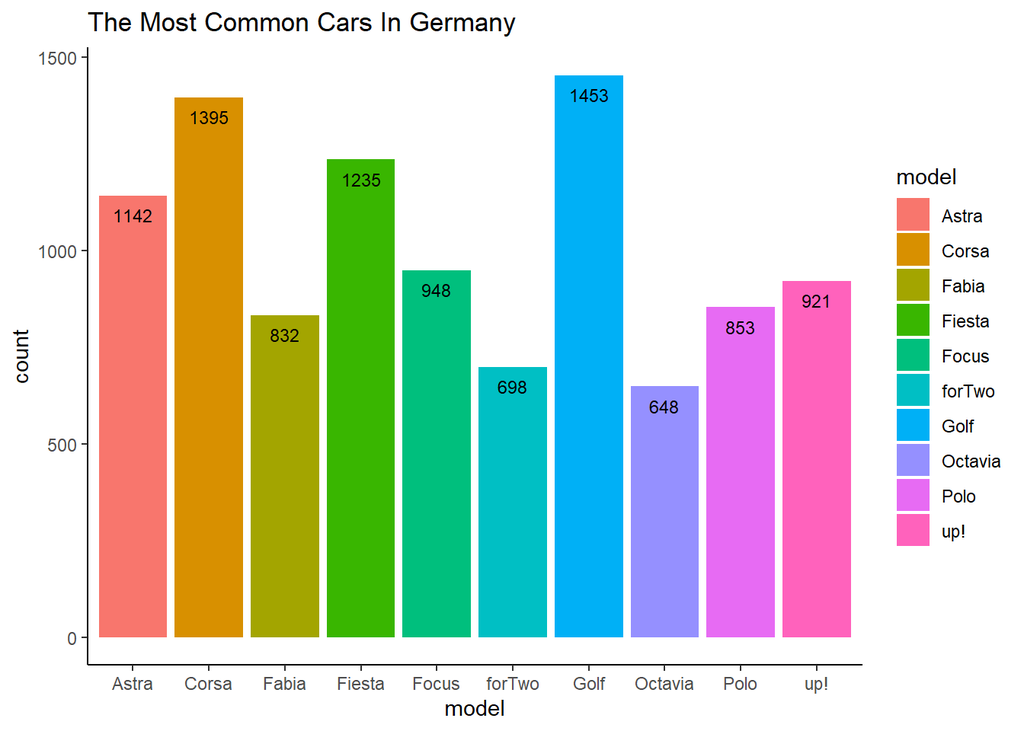

```r
ggplot(data = counts2)+
  geom_col(mapping = aes(x= model, y= count, fill = model))+
  labs(x="model",y="count",xlab="model",ylab="count" )+
  theme_classic()+
  geom_text(aes(x = model, y = count - 50, label = count), size = 3) +
  ggtitle("The Most Common Cars In Germany ")
```

##### 4.0.0.1.3 **least common cars in germany**

```r
counts3 <- counts %>%
  arrange(desc(counts$count)) %>%
  tail(10) %>%
  print()
```

```
## # A tibble: 10 x 3
## # Groups:   make [5]
##    make       model                     count
##    <chr>      <chr>                     <int>
##  1 Trucks-Lkw "Ford"                        1
##  2 Volkswagen "Cross Golf"                  1
##  3 Volkswagen "Golf GTE"                    1
##  4 Volkswagen "T4 Allstar"                  1
##  5 Volkswagen "T5 Shuttle"                  1
##  6 Volvo      ""                            1
##  7 Volvo      "S60 Cross Country"           1
##  8 Volvo      "XC70"                        1
##  9 Zhidou     "D2S"                         1
## 10 smart      "city-coupÃ©/city-cabrio"     1
```

#### 4.0.0.2 **What is the average price of German cars by year, make type?**

##### 4.0.0.2.1 **the average price for a german car over years**

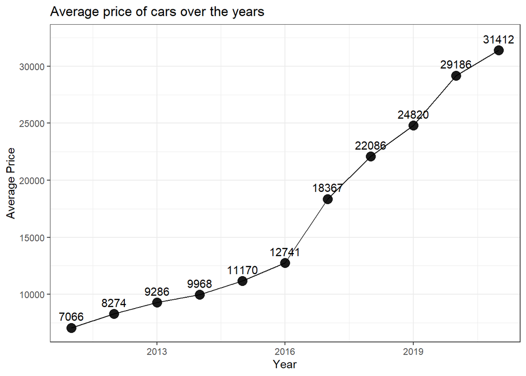

```r
CarPriceByYear <- My_cleaned_data %>%
  group_by(year) %>%
  summarize(average_price = round(mean(price)))

ggplot(data = CarPriceByYear)+
  geom_point(mapping = aes(x= year, y= average_price), size = 4, alpha =0.9) +
  geom_line(mapping = aes(x= year, y= average_price) ) +
  geom_text(mapping = aes(x=year,y=average_price + 1000,label=average_price))+
  labs(y = "Average Price", x = "Year", ylab = "Average Price") +
  # Change the theme to make the plot more readable
  theme_bw() +
  ggtitle("Average price of cars over the years")
```

##### 4.0.0.2.2 **the average price for a german car by company the most expensive 15 and the cheapest 15**

```r
# the most Expensive
CarsPriceByMake1 <- My_cleaned_data %>%
  group_by(make) %>%
  summarize(average_price2 = round(mean(price))) %>%
  arrange(desc(average_price2)) %>%
  head(15) %>%
  print()
```

```
## # A tibble: 15 x 2
##    make        average_price2
##    <chr>                <dbl>
##  1 Maybach             450479
##  2 Ferrari             324028
##  3 Lamborghini         305699
##  4 McLaren             204967
##  5 Rolls-Royce         196267
##  6 Bentley             184434
##  7 Aston               163443
##  8 Corvette            110160
##  9 Porsche              90330
## 10 FISKER               69900
## 11 Maserati             69119
## 12 Alpina               66046
## 13 Polestar             64150
## 14 Tesla                62524
## 15 Morgan               61950
```

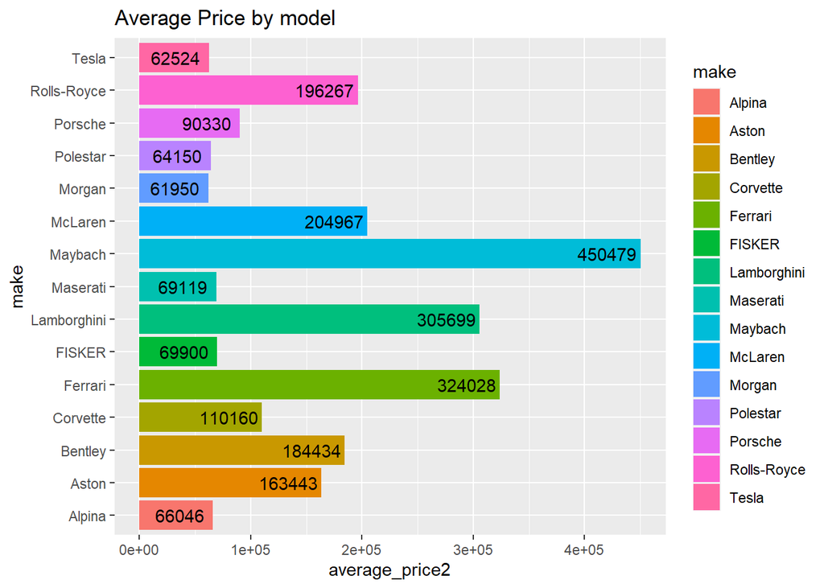

```r
ggplot(data = CarsPriceByMake1)+
  geom_col(mapping = aes(x=make, y=average_price2, fill = make))+
  geom_text(aes(x=make,y=average_price2 - 30000, label = average_price2))+
  labs(title = "Average Price by model")+
  coord_flip()
```

```r
# the cheapest
CarsPriceByMake2 <- My_cleaned_data %>%
  group_by(make) %>%
  summarize(average_price2 = round(mean(price))) %>%
  arrange(average_price2) %>%
  head(15) %>%
  print()
```

```
## # A tibble: 15 x 2
##    make              average_price2
##    <chr>                      <dbl>
##  1 Brilliance                  1500
##  2 Trailer-AnhÃ¤nger           2750
##  3 Daihatsu                    4927
##  4 Lancia                      6289
##  5 Tazzari                     6500
##  6 Chevrolet                   6721
##  7 DAF                         6850
##  8 9ff                         7000
##  9 Piaggio                     7122
## 10 Microcar                    7586
## 11 Iveco                       7722
## 12 Others                      8170
## 13 Trucks-Lkw                  8200
## 14 smart                       8254
## 15 Dacia                       9155
```

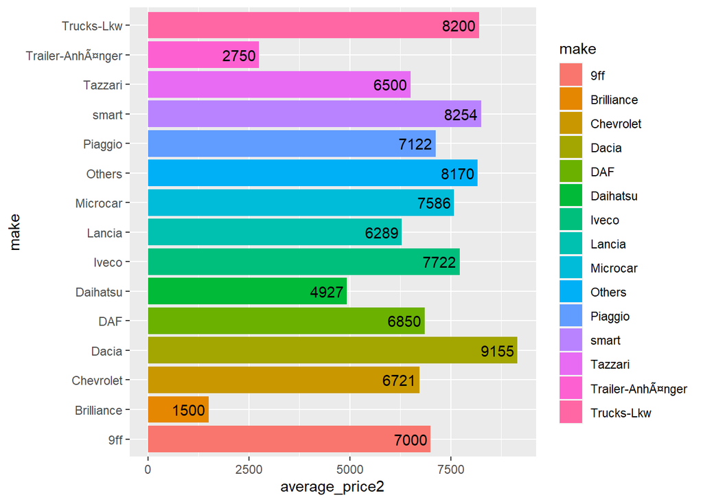

```r
ggplot(data = CarsPriceByMake2)+
  geom_col(mapping = aes(x=make, y=average_price2, fill = make))+
  geom_text(aes(x=make,y=average_price2 - 500, label = average_price2))+
  coord_flip()
```